# Finding your way around dgraphs

`dgraphs` turns numerical observations into graphs and provides tools to inspect their connectivity, paths and geometry. Start with the question you want to answer. Use the task map, follow a small workflow, then consult the complete catalog.

## Choose a starting point

| Your question | Entry point | Choice that matters |
| --- | --- | --- |
| Which nearby observations should be linked? | `create.mknn.graph()` or `create.sknn.graph()` | Mutual neighbors require agreement; symmetric neighbors accept either direction. |
| Can I adapt a Gabriel graph while retaining connectivity? | `create.ian.graph()` | Build the optional IAN backend first; inspect completion, graphs and affinity diagnostics. |
| How should support adapt to sampling density? | `create.rknn.graph()` or `create.cknn.graph()` | Fixed radius, local radius rules, or a geometric mean of local scales. |
| Should overlapping neighborhoods define edges? | `create.single.iknn.graph()` | Intersection graphs can connect points that are not direct nearest neighbors. |
| How sensitive is my graph to neighborhood size? | Plural constructors such as `create.sknn.graphs()` | Inspect a parameter sequence and its component counts. |
| Do I need paths between every pair? | `graph.connected.components()`, then constructor repair controls | Bridge edges make a modeling assumption across gaps. |
| How far apart are vertices along this graph? | `graph.geodesic.distances()` | Edge values must represent additive lengths or costs. |
| Does the graph preserve known distances? | `summarize.isometry.deviation()` | Requires a reference distance matrix with matching vertex order. |
| Do I need coordinates for a graph? | `graph.embedding()` or `graph.spectral.embedding()` | A visualization layout and a spectral representation serve different purposes. |
| How can I generate points with known geometry? | `sample.synthetic.geometry()` | Pair a geometry with a compatible sampling specification. |

For powered path costs and complete-versus-restricted comparisons, read Density-sensitive paths with Fermat distances. For the saved surface experiments, read Fermat paths on surfaces and the companion study of sampling density, curvature, and geodesic recovery.

## A first graph

Use a finite numeric matrix with observations in rows. This example samples a circle, constructs a symmetric nearest-neighbor graph, requests connectivity repair, and measures distances on the final graph.

```r
library(dgraphs)
points <- sample.synthetic.geometry(
  synthetic.circle(),
  synthetic.sampling.grid.interval(0, 2 * pi, endpoints = "exclude.lower"),
  n = 24, seed = 17
)
X <- points$predictors
graph <- create.sknn.graph(X, k = 2, connect.components = TRUE)
print(graph)
```

```
#> Symmetric kNN graph
#> Number of vertices: 24
#> Number of edges: 24
#> k: 2
#> Connected components before MST augmentation: 1
#> Connected components after MST augmentation: 1
#> MST bridge edges added: 0
#> Connection method: component.mst
#> Bridge method: none
#> Neighbor method: exact
```

```r
length(unique(graph.connected.components(graph)))
```

```
#> [1] 1
```

```r
D <- graph.geodesic.distances(graph)
round(D[1:4, 1:4], 3)
```

```
#>       [,1]  [,2]  [,3]  [,4]
#> [1,] 0.000 0.261 0.522 0.783
#> [2,] 0.261 0.000 0.261 0.522
#> [3,] 0.522 0.261 0.000 0.261
#> [4,] 0.783 0.522 0.261 0.000
```

```r
ig <- as_igraph(graph)
c(vertices = igraph::vcount(ig), edges = igraph::ecount(ig))
```

```
#> vertices    edges
#>       24       24
```

Distances here sum straight chords between observed coordinates. They approximate circular arc distances through a finite graph; they are not exact continuous arc lengths. For a longer comparison of graph families, repair and diagnostics, read Constructing and Diagnosing Data-Derived Graphs. For sampling and embedding details, read Synthetic geometry and point sampling.

## Constructing a standard graph

Use `create.graph(type, ...)` when you want a familiar topology or a small example. The required `type` selects the graph; arguments following `n` must be named. Every result uses the same graph accessors as a data-derived graph.

| Type | Arguments | Edge lengths |
| --- | --- | --- |
| `"empty"` | `n` (zero allowed) | Absent |
| `"complete"` | `n` | Absent |
| `"chain"` | `n` or `x`; optional `span = 1`, `y` | One, or absolute coordinate differences |
| `"cycle"` | `n >= 3` | Absent |
| `"complete_bipartite"` | `sizes = c(n1, n2)` | Absent |
| `"star"` | `arms`: positive edge counts along each arm | Absent |
| `"random"` | `n`, `mean.degree`; optional `connected = TRUE`, `seed` | Independent uniform lengths on [0.5, 1.5] |
| `"circle"` | `n >= 3`; optional `sampling`, `edge.length`, `seed` | Shorter unit-circle arcs (default) or chords |

```r
standard <- list(
  empty = create.graph("empty", n = 5),
  complete = create.graph("complete", n = 5),
  chain = create.graph("chain", n = 5, span = 2, labels = 101:105),
  cycle = create.graph("cycle", n = 5),
  complete_bipartite = create.graph("complete_bipartite", sizes = c(2, 3)),
  star = create.graph("star", arms = c(1, 2, 1)),
  random = create.graph("random", n = 5, mean.degree = 2, seed = 23),
  circle = create.graph("circle", n = 5, sampling = "uniform",
                        edge.length = "chord")
)
knitr::kable(data.frame(
  type = names(standard),
  vertices = vapply(standard, graph.order, integer(1)),
  edges = vapply(standard, function(g) nrow(graph.edges(g)), integer(1)),
  stored.lengths = vapply(standard, function(g) !is.null(graph.lengths(g)), logical(1))
), row.names = FALSE)
```

| type | vertices | edges | stored.lengths |
| --- | --- | --- | --- |
| empty | 5 | 0 | FALSE |
| complete | 5 | 10 | FALSE |
| chain | 5 | 7 | TRUE |
| cycle | 5 | 5 | FALSE |
| complete_bipartite | 5 | 6 | FALSE |
| star | 5 | 4 | FALSE |
| random | 5 | 5 | TRUE |
| circle | 5 | 5 | TRUE |

For chains, `span` counts positions on **each side**, so an interior vertex has at most `2 * span` neighbors. This differs from `k` in nearest-neighbor workflows. Optional `x` sorts vertices by coordinate, with ties resolved by input position; `y` and `labels` follow the same ordering. The sorted-to-input mapping is `metadata$order`. An ordinary star has all arm counts equal to one; larger counts subdivide its arms.

A cycle describes topology. A circle also records unit-circle coordinates in `metadata$coordinates` and angles in `metadata$angles`. Circle sampling is `"random"` by default; `"uniform"` spaces angles equally. Choose `edge.length = "chord"` for Euclidean edge lengths or `"arc"` for shorter circular arcs. A shorter arc can cross an unsampled gap; graph shortest paths still follow the edges actually present. Arc lengths are measured in radians on the unit circle, not squared distances or conductances.

Random graphs have `floor(n * mean.degree / 2)` edges. A connected graph needs at least `n - 1`, and an impossible request errors. With `connected = TRUE`, a growing random tree precedes additional edges; the result is not a uniform draw from all connected graphs. With `connected = FALSE`, edges are sampled uniformly without replacement from all vertex pairs. Candidate storage is quadratic in the number of vertices, so this generator is intended for small examples. For both random graphs and randomly sampled circles, an explicit `seed` restores the caller’s random state after generation; `seed = NULL` uses and advances the current stream. Uniform circle sampling uses no random numbers. Unknown or irrelevant arguments error instead of being ignored.

## Conventions that affect your choice

### A common graph object

Every graph constructor returns a `dgraph`, including basic fixtures. Use `graph.adjacency(graph)` for its neighbor lists, `graph.lengths(graph)` for aligned lengths, and `graph.edges(graph)` for one row per undirected edge. `graph.order(graph)` includes isolated vertices. A bare `adj.list` has one integer vector per vertex, containing **1-based** neighbor indices; `length.list` gives the corresponding finite, nonnegative lengths.

For one transition release, `graph$adj_list` and `graph$weight_list` remain available without warnings. They match the final-stage adjacency and lengths, including vertex labels; `weight_list` is `NULL` when no lengths are stored. Treat these fields as read-only snapshots and use the accessors in new code. Native constructor results also retain `edge_matrix` for this release; new code should use `graph.edges(graph)`.

`dgraph(adj.list, length.list)` validates reciprocal edges and values, rejects duplicates and self-loops, and sorts neighbors and values together. Omit `length.list` for topology alone. A stored zero-length edge remains an edge. `as_igraph(graph)` preserves isolates, lengths as the `length` attribute, and other named edge attributes. For igraph distance calculations, explicitly use `weights = igraph::E(ig)$length`. Raw-list matrix conversions retain `weight.list` for quantities that need not represent distances.

Path-search results contain their graph in `$graph` and paths in `$shortest.paths`; a parameter sequence contains separate graph objects. Subgraphs use compact indices and record `metadata$original.vertices`. `create.graph(type, ..., labels = ...)` assigns vertex labels independently of adjacency indices. For example, `labels = 101:110` names ten vertices without changing their internal indices `1:10`.

### Neighborhood sizes and edge quantities

All sequence constructors take an explicit, strictly increasing `k.values` vector with `1 <= k < n`. In coordinate and graph-geodesic intersection workflows, **k counts other vertices**. Each cover explicitly includes its source plus those neighbors. Equal distances are resolved by vertex index, including coincident observations. Coordinate ANN search uses an exact fallback when its boundary candidates are tied. The specialized `knn.metric = "linf.simplex"` search currently evaluates all candidates to honor the same tie rule, with quadratic distance-evaluation cost. It shares `linf.simplex.distances()`’s general shortest-path solver, including paths through intermediate faces. Legacy endpoint-face simplex caches are rejected and must be rebuilt; Euclidean caches remain compatible. Search uses row-wise working memory rather than storing an all-pairs distance matrix.

```r
X.line <- matrix(c(0, 1, 3, 6), ncol = 1)
initial <- create.single.iknn.graph(X.line, k = 1, prune.method = "none",
                                  connect.components = FALSE, verbose = FALSE)
rebuilt <- create.geodesic.iknn.graph(initial, k = 1)
rebuilt$metadata$neighborhood
```

```
#> $k
#> [1] 1
#>
#> $effective.k
#> [1] 1 1 1 1
#>
#> $metric
#> [1] "graph.geodesic"
#>
#> $self
#> [1] "explicit"
#>
#> $ties
#> [1] "distance.then.vertex.index"
#>
#> $convention.version
#> [1] 3
```

Graph-geodesic construction errors if any component has fewer than `k + 1` vertices. Choose `small.component = "truncate"` to use all reachable other vertices instead; `metadata$neighborhood$effective.k` records the count for each vertex, including zero for isolates. Iterated construction applies the same requested k and component policy at every rebuild.

| Construction | Edge-length contract |
| --- | --- |
| Mutual and symmetric kNN | Euclidean distance between endpoints. |
| Fixed/adaptive radius and continuous kNN | Euclidean distance; radius rules govern which edges exist. |
| Coordinate intersection kNN | Minimum summed metric distance through a common cover member, in working coordinates after any PCA. |
| Geodesic intersection kNN | Previous-graph shortest-path distance between the new endpoints. |
| Nerve of arbitrary sets | No lengths; cardinality of overlap is the `overlap` edge attribute. |

An overlap score or conductance is not a travel distance. Read named attributes with `graph.edge.attribute(graph, "overlap")`, or the corresponding column of `graph.edges(graph)`. A length-based operation rejects a graph with no lengths; `graph.geodesic.distances(graph, distance = "hop")` explicitly requests unweighted distance. `graph.spectrum(graph)` uses the unweighted Laplacian. `graph.embedding(graph)` is unweighted by default; choose an `edge.attribute` and `transform = "identity"` or `"reciprocal"` explicitly. Layout values must be strictly positive, so zero lengths require a separate, explicit choice of layout quantity.

### Connectivity, stages and cost

Mutual, symmetric and radius constructors can leave components separate. Request `connect.components = TRUE` when bridges are appropriate. Exact component-MST repair joins components through shortest Euclidean bridges; the ANN candidate version can fall back to exact search. A global minimum spanning tree is another repair option. `join.graphs()` identifies one vertex from each of two graphs and preserves aligned lengths and attributes.

`graph.stages(graph)` lists the stored stages. Every graph has `final`; constructors may additionally retain `raw`, `pruned`, `raw.repaired`, `pruned.repaired` and `repaired.pruned`. Pass the same `stage` to any accessor, `as_igraph()` or `graph.geodesic.distances()`. A missing stage errors, and stage selection never prunes, repairs or reconstructs a graph. The geodesic intersection constructor stores only `final` because it performs no pruning or repair. Symmetric kNN’s `graph.detail = "minimal"` requires both disabled.

Disconnected pairs have infinite distances. All-pairs distances require a quadratic-size matrix; request selected vertices when possible. Geometric pruning and exact component bridging can be expensive even with ANN neighbor search. Native construction is serial; thread controls do not promise native parallel execution.

### Distances and stored routes

Use `graph.geodesic.distances()` for a matrix of distances. Supply exactly one of an existing `graph` or a coordinate matrix `points`. With coordinates, `graph.type = "sknn"` requires an explicit `k` and builds a symmetric kNN graph without pruning or connectivity repair. `graph.type = "mst"` builds a Euclidean minimum spanning tree and does not accept `k`. Setting `k = 1` never changes the construction method. Coincident observations remain connected by zero-length edges when selected by the construction.

```r
line.points <- matrix(c(0, 0, 1, 10, 11), ncol = 1)
D.tree <- graph.geodesic.distances(points = line.points, graph.type = "mst")
D.neighbors <- graph.geodesic.distances(points = line.points,
                                       graph.type = "sknn", k = 1)
knitr::kable(data.frame(
  pair = c("Coincident observations", "First to last observation"),
  tree.distance = c(D.tree[1, 2], D.tree[1, 5]),
  symmetric.neighbor.distance = c(D.neighbors[1, 2], D.neighbors[1, 5])
), row.names = FALSE, col.names = c("Pair", "Tree distance", "Symmetric kNN distance"))
```

| Pair | Tree distance | Symmetric kNN distance |
| --- | --- | --- |
| Coincident observations | 0 | 0 |
| First to last observation | 11 | Inf |

Both calculations are exact shortest-path distances on their chosen graphs. Neither construction guarantees exact continuous manifold geodesics. The symmetric-neighbor example has disconnected components, represented by `Inf`. `vertices` selects matrix rows and columns in the requested order; paths may still pass through any vertex in the graph. `distance = "hop"` counts edges; `distance = "length"` requires stored lengths. To reuse a graph or choose additional construction options, construct it first and pass `graph = g`.

Use `create.path.graph()` when the routes themselves matter. Its `h.values` argument specifies strictly increasing positive integer **maximum hop counts**; a hop traverses one edge. It always returns a named collection, including when only one limit is requested. Select a member before retrieving a route.

```r
weighted.graph <- dgraph(
  list(c(2L, 3L), c(1L, 3L, 4L), c(1L, 2L), 2L),
  list(c(5, 1), c(5, 1, 1), c(1, 1), 1))
paths <- create.path.graph(weighted.graph, h.values = c(2, 3))
knitr::kable(compare.paths(paths, from = 1, to = 4)[,
  c("h", "path_exists", "path_length", "n_hops")], row.names = FALSE,
  col.names = c("Hop limit", "Route exists", "Route length", "Hops used"))
```

| Hop limit | Route exists | Route length | Hops used |
| --- | --- | --- | --- |
| 2 | TRUE | 6 | 2 |
| 3 | TRUE | 3 | 3 |

```r
get.shortest.path(paths[["h_2"]], from = 1, to = 4)
```

```
#> $path
#> [1] 1 2 4
#>
#> $length
#> [1] 6
#>
#> $hops
#> [1] 2
```

```r
get.shortest.path(paths[["h_3"]], from = 4, to = 1)
```

```
#> $path
#> [1] 4 2 3 1
#>
#> $length
#> [1] 3
#>
#> $hops
#> [1] 3
```

With two hops, the best route has length 6; allowing three hops lowers it to 3. The returned route’s edges, stored length and hop count agree. Each result stores a graph of reachable pairs in `$graph`, with a `hops` edge attribute. `get.shortest.path()` returns a vertex sequence, length and hop count, or `NULL` when the pair is unreachable within the selected limit. Both directions are supported; a vertex’s route to itself has length and hop count zero. For equal-length routes, fewer hops are preferred. These all-pairs route collections can require substantial memory; use modest hop limits when possible.

For a path expressed as coordinates, `path.length()` sums Euclidean segment lengths and `subdivide.path()` includes both endpoints at equally spaced distances along the polyline. Points on opposite sides of a corner need not have equal straight-line distances from each other.

```r
polyline <- rbind(c(0, 0), c(1, 0), c(1, 2))
path.length(polyline) # 3
```

```
#> [1] 3
```

```r
subdivide.path(polyline, n.subdivision.pts = 5)
```

```
#>      [,1] [,2]
#> [1,] 0.00 0.00
#> [2,] 0.75 0.00
#> [3,] 1.00 0.50
#> [4,] 1.00 1.25
#> [5,] 1.00 2.00
```

```r
path.dist(1:3, polyline) # normalized cumulative distances: 0, 1/3, 1
```

```
#> [1] 0.0000000 0.3333333 1.0000000
```

The five subdivision rows correspond to arc distances 0, 0.75, 1.5, 2.25 and 3. Repeated consecutive points contribute zero length. For a singleton or a path whose points all coincide, length and normalized cumulative distances are zero, and subdivision repeats that location. Empty paths are rejected; subdivision requires at least two output points.

### Positive spectra and spectral coordinates

`graph.spectrum()` uses the final graph’s unweighted combinatorial Laplacian, regardless of stored lengths. Its `nev` counts **positive eigenpairs**, ordered from smallest upward. Every connected component, including an isolated vertex, contributes one omitted zero mode. The spectrum records this count as `nullity` and preserves component IDs in vertex order. `nev = NULL` requests all positive modes; use a small explicit count for large graphs. Requests larger than the number of positive modes error rather than silently changing the count.

```r
chain <- create.graph("chain", n = 8)
spectrum <- graph.spectrum(chain, nev = 3)
round(spectrum$evalues, 6)
```

```
#> [1] 0.152241 0.585786 1.234633
```

```r
spectrum$nullity
```

```
#> [1] 1
```

```r
coordinates <- graph.spectral.embedding(spectrum, dim = 2)
dim(coordinates)
```

```
#> [1] 8 2
```

The three eigenvalues are approximately 0.152241, 0.585786 and 1.234633; the embedding uses the first two. `use.R = TRUE` has the same output contract. Both backends honor `return.Laplacian = TRUE` and `return.dense`; sparse output uses the optional Matrix package. The native backend uses a sparse solver for partial spectra and a dense solver for the full spectrum. The R backend uses a full dense solve, so both an R solve and a full native spectrum require quadratic memory. A documented absolute tolerance separates computed zero modes from positive modes; an unresolved separation errors explicitly.

Pass the spectrum object to `graph.spectral.embedding()`. Its default `scale = "none"` uses orthonormal eigenvectors; `scale = "inverse.sqrt"` scales each column by the inverse square root of its eigenvalue. With every positive mode on a connected graph, squared distances in the latter embedding equal effective resistance. With fewer modes it is a truncated representation. Neither coordinate choice generally reproduces graph shortest-path distances. Signs and bases in repeated eigenspaces can differ between solvers. Include the whole tied eigenspace when comparing distances between embeddings.

Disconnected graphs have spectra, but no common embedding is assigned: select a component with `create.subgraph(graph, which(spectrum$components == id))`, compute its spectrum and embed it separately. Distances between independently embedded components have no defined meaning. Empty and singleton graphs have no positive-dimensional spectral embedding.

### Plotting a graph and reusing its layout

`graph.embedding()` computes coordinates without drawing. The standard `plot()` method for a `dgraph` computes a two-dimensional layout only when coordinates are absent and invisibly returns the coordinates actually drawn. Use `vertex.values` for numeric values mapped through a palette, or `vertex.colors` for explicit colors; supplying both errors. Constant numeric values use the palette midpoint. Every undirected edge is drawn once.

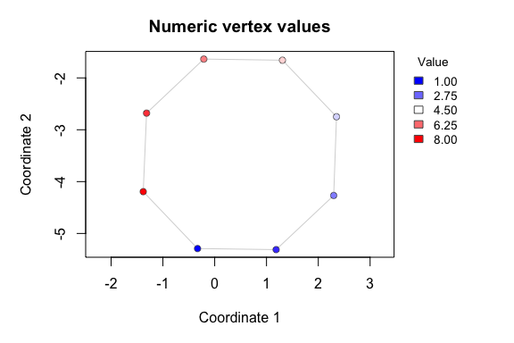

```r
cycle <- create.graph("cycle", n = 8)
set.seed(4101)
xy <- plot(cycle, vertex.values = seq_len(8), main = "Numeric vertex values")
```

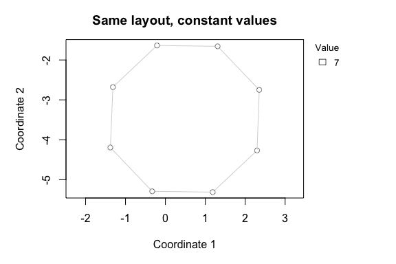

```r
plot(cycle, coordinates = xy, vertex.values = rep(7, 8),
     main = "Same layout, constant values")
```

The same `stage` controls both layout computation and drawn edges. For three-dimensional coordinates, choose an explicit two-column projection; the plotting method never silently discards a coordinate. Layout generation itself remains available in both two and three dimensions.

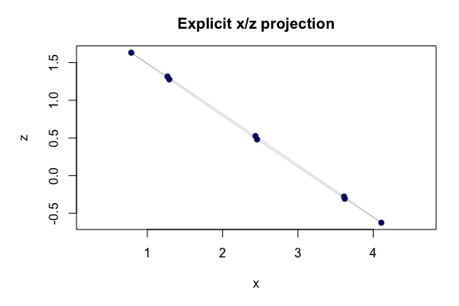

```r
set.seed(4102)
xyz <- graph.embedding(cycle, dim = 3)
colnames(xyz) <- c("x", "y", "z")
plot(cycle, coordinates = xyz, projection = c(1, 3), vertex.colors = "navy",
     main = "Explicit x/z projection")
```

### Reuse an expensive computation

Keep a constructed graph for repeated `graph.geodesic.distances()` calls; this reuses its edges, not a memoized distance matrix. Save `D` yourself when reusing the same distances. Coordinate input constructs a fresh graph for each distance call. Geodesic intersection and iterated intersection workflows deliberately build on existing graph metrics.

`create.sknn.graphs()` reuses one ANN search across its `k` values. A single symmetric constructor also accepts ordered, 1-based, non-self `knn.index` rows with `neighbor.method = "ann"`; these must correspond to the same input points. Intersection constructors expose `knn.cache.path` and `knn.cache.mode`: `"read"` requires a valid cache, `"write"` replaces it, and `"readwrite"` creates a missing cache but rejects an existing invalid one. Format version 3 caches store only non-self neighbors and check point values, row order, metric, working-coordinate preprocessing and maximum k. Old cache formats are rejected. The adaptive-radius sequence has a batched ANN backend. These are distinct contracts; there is no universal public neighbor-cache object shared by all constructors. Internal cache and native solver helpers are not installed public functions to call directly.

## Function catalog

The catalog covers all 119 explicit public exports exactly once; 44 registered S3 methods are described separately through object workflows. Internal helpers and development applications are not public entry points. Links open the exact help included with this build, offline.

Each row is one explicit export. Open exact arguments and examples with `help("create.sknn.graph", package = "dgraphs")`, replacing the name as needed. The [package reference manual](https://CRAN.R-project.org/package=dgraphs/dgraphs.pdf) describes the released version; newly added functions require the corresponding release or development installation.

### Graph construction and parameter sequences

| Function | Purpose |
| --- | --- |
| `create.ian.graph()` | Adapt local scales and prune a Gabriel graph, preserving connectivity by default; requires the optional backend. |
| `build.ian.backend()` | Build the optional pinned IAN module on macOS arm64 and return its path. |
| `create.mknn.graph()` | Build a mutual Euclidean nearest-neighbor graph, with optional pruning and repair. |
| `create.mknn.graphs()` | Build mutual-neighbor graphs across a range of neighborhood sizes. |
| `create.sknn.graph()` | Build a symmetric Euclidean nearest-neighbor graph, with optional pruning and repair. |
| `create.sknn.graphs()` | Build a symmetric-neighbor sequence using a shared ANN search. |
| `create.rknn.graph()` | Build a fixed-radius or adaptive-radius Euclidean graph. |
| `create.rknn.graphs()` | Vary the local neighborhood scale in adaptive-radius graphs. |
| `create.cknn.graph()` | Build a continuous-kNN graph using geometric-mean local scales. |
| `create.single.iknn.graph()` | Build one intersection-neighborhood graph with optional pruning. |
| `create.iknn.graphs()` | Build an intersection-neighborhood sequence and its pruning branches. |
| `create.geodesic.iknn.graph()` | Rebuild intersection neighborhoods using an existing graph’s distances. |
| `create.iterated.iknn.graphs()` | Repeat intersection construction in successive graph metrics. |
| `build.iknn.graphs.and.selectk()` | Select an intersection neighborhood size using structural or label-mixing stability. |
| `create.cmst.graph()` | Complete a Euclidean minimum spanning tree using an edge-length quantile. |
| `create.threshold.distance.graph()` | Connect points satisfying a distance threshold. |
| `nerve.graph()` | Construct a graph from overlaps between sets in a cover. |

### Basic graphs and representation

| Function | Purpose |
| --- | --- |
| `create.graph()` | Construct standard graph types, labeled chains, random graphs and sampled circles. |
| `dgraph()` | Validate aligned neighbor, length and attribute lists as an undirected graph. |
| `graph.adjacency()` | Read the neighbor list for a stored stage. |
| `graph.lengths()` | Read aligned lengths, or NULL when absent. |
| `graph.edges()` | Read one ordered row per undirected edge, with lengths and attributes. |
| `graph.order()` | Count vertices, including isolates. |
| `graph.stages()` | List stages actually stored in a graph. |
| `graph.edge.attribute()` | Read an explicitly named edge attribute. |
| `as_igraph()` | Convert a dgraph stage to an undirected igraph object. |
| `convert.adjacency.list.to.adjacency.matrix()` | Convert bare neighbor lists to an adjacency matrix. |
| `convert.weighted.adjacency.matrix.to.adjacency.list()` | Convert a weighted adjacency matrix to aligned lists. |
| `convert.adjacency.to.edge.matrix()` | Extract an edge matrix and optional aligned weights. |
| `count.edges()` | Count undirected edges once from reciprocal neighbor lists. |
| `compare.adj.lists()` | Compare neighbor sets, optionally reporting differences. |
| `edge.diff()` | Find edges present in one graph but absent from another. |
| `identical.vertex.set.weighted.graph.similarity()` | Compare weighted graphs on the same vertex set. |

### Connectivity and graph editing

| Function | Purpose |
| --- | --- |
| `graph.connected.components()` | Assign a component identifier to every vertex. |
| `convert.to.undirected()` | Add reciprocal links to a directed adjacency list. |
| `rm.self.loops()` | Remove each vertex from its own neighbor list. |
| `join.graphs()` | Identify one vertex from each of two graphs. |
| `create.subgraph()` | Extract the graph induced by selected vertices. |
| `create.grid.graph()` | Refine graph edges toward approximately uniform spatial spacing. |

### Paths and distances

| Function | Purpose |
| --- | --- |
| `fermat.knn()` | Find exact complete-graph Fermat nearest neighbors. |
| `create.fermat.sknn.graph()` | Union-symmetrize exact Fermat neighbor selections. |
| `fermat.distances()` | Compute complete-graph sample Fermat distances or explicit graph-restricted alternatives. |
| `linf.simplex.distances()` | Compute intrinsic Euclidean-length distances on the max-normalized simplex, optionally returning shortest paths. |
| `graph.geodesic.distances()` | Compute shortest-path distances for a supported graph object and stage. |
| `shortest.path()` | Legacy raw-list distance interface retained for one transition release; use `graph.geodesic.distances()` in new code. |
| `compute.graph.distance()` | Compute a weighted shortest-path distance between two vertices. |
| `compute.graph.diameter()` | Compute a weighted graph diameter. |
| `get.shortest.path()` | Recover a shortest vertex path. |
| `geodesic.disk()` | Find a graph neighborhood within a distance radius. |
| `geodesic.knn()` | Find nearest vertices in a graph metric. |
| `geodesic.knnx()` | Find graph-metric nearest neighbors for query vertices. |
| `create.path.graph()` | Construct a collection of path results for one or several hop limits. |
| `create.plm.graph()` | Build a path-length-matrix graph structure. |
| `compare.paths()` | Compare paths obtained under different hop limits. |
| `minh.limit()` | Find a minimum hop limit that permits a path. |
| `path.length()` | Measure Euclidean length along a coordinate path. |
| `path.dist()` | Compute normalized cumulative distance along a vertex path. |
| `subdivide.path()` | Include both endpoints and space points equally along a polyline; repeat the location for zero-length paths. |

### Edge lengths and pruning

| Function | Purpose |
| --- | --- |
| `extract.trajectory.edge.lengths()` | Extract stored edge lengths along a graph vertex trajectory. |
| `wgraph.prune.long.edges()` | Prune edges using length constraints on alternative paths. |

### Diagnostics, endpoints and packing

| Function | Purpose |
| --- | --- |
| `compute.graph.summary.pmf()` | Represent a degree, weight, component-size or label-neighborhood summary as probability masses. |
| `graph.summary.divergence()` | Compare graph-summary probability masses using a chosen divergence. |
| `jensen.shannon.divergence()` | Measure Jensen-Shannon divergence between probability distributions. |
| `compute.graph.summary.stability()` | Track summary divergence between consecutive graphs. |
| `compute.stability.metrics()` | Summarize structural stability of an intersection-graph sequence. |
| `compute.geodesic.stats()` | Summarize geodesic growth around grid vertices. |
| `compute.vertex.geodesic.stats()` | Inspect geodesic growth around one grid vertex. |
| `compute.graph.endpoint.scores()` | Score directional concentration in a 3D embedding using graph neighborhoods. |
| `detect.graph.endpoints()` | Select and consolidate candidate geometric endpoints. |
| `geodesic.core.endpoints()` | Detect endpoints using a graph-geodesic core. |
| `detect.local.extrema()` | Find graph-local maxima or minima of vertex values. |
| `vertices()` | Extract vertices through the generic, currently for local-extrema results. |
| `remove.knn.outliers()` | Identify and remove observations with unusual nearest-neighbor distances. |
| `create.maximal.packing()` | Select separated vertices at a requested graph scale. |
| `validate.maximal.packing()` | Check separation and maximality of a vertex packing. |
| `verify.maximal.packing()` | Verify a packing result using its graph and scale. |
| `isometry.scale()` | Fit a global scale aligning estimated distances with reference distances. |
| `isometry.rel.rms.error()` | Measure target-normalized root-mean-square distance error. |
| `isometry.rel.abs.error()` | Summarize quantiles of relative absolute distance errors. |
| `isometry.distortion.quantiles()` | Summarize multiplicative distance distortion. |
| `isometry.distance.correlations()` | Compare estimated and reference distances by correlation. |
| `isometry.geodesic.diagnostics()` | Diagnose shortcuts and distance-scale-dependent geodesic bias. |
| `summarize.isometry.deviation()` | Combine scale, error, distortion and correlation diagnostics. |

### Spectral methods and graph display

| Function | Purpose |
| --- | --- |
| `graph.spectrum()` | Compute the smallest positive Laplacian eigenpairs, with component nullity. |
| `graph.spectral.embedding()` | Embed a connected graph from its spectrum, with explicit coordinate scaling. |
| `graph.embedding()` | Compute a graph visualization layout. |

### Synthetic geometry and embedding

| Function | Purpose |
| --- | --- |
| `synthetic.quadform()` | Specify a flat or quadratic geometry with intrinsic and ambient dimensions. |
| `synthetic.circle()` | Specify a circle or circular arc. |
| `synthetic.helix()` | Specify a helical curve. |
| `synthetic.trefoil()` | Specify the supported trefoil parameterization. |
| `synthetic.sphere.cap()` | Specify a spherical cap over a planar footprint. |
| `synthetic.torus.patch()` | Specify a torus patch over two angular parameters. |
| `synthetic.simplex()` | Specify a compositional simplex with a given number of parts. |
| `synthetic.stratum.point()` | Specify a zero-dimensional point stratum. |
| `synthetic.stratum.segment()` | Specify a one-dimensional line-segment stratum. |
| `synthetic.stratum.rectangle()` | Specify a two-dimensional rectangular stratum. |
| `synthetic.stratified()` | Assemble compatible strata and optional junction metadata; general sampling is not implemented. |
| `synthetic.point.line.junction()` | Specify a point and segment junction. |
| `embed.synthetic.geometry()` | Deterministically map supported latent coordinates to ambient coordinates. |
| `embed.quadform.surface()` | Lift two-column coordinates using the versioned Geometry Lab quadratic arithmetic. |
| `quadform.gradient()` | Evaluate gradients of quadratic height functions. |
| `quadform.metric()` | Evaluate the induced metric of a quadratic geometry. |
| `edge.lengths.synthetic.geometry()` | Measure lifted straight latent segments; currently supports quadforms only. |
| `validate.synthetic.geometry()` | Validate a geometry specification or latent coordinate matrix. |

### Point sampling

| Function | Purpose |
| --- | --- |
| `sample.synthetic.geometry()` | Realize geometry-only points with an explicit seed or random-state plan. |
| `synthetic.sampling.uniform.interval()` | Specify uniform interval draws and their ordering. |
| `synthetic.sampling.grid.interval()` | Specify deterministic interval points and endpoint inclusion. |
| `synthetic.sampling.uniform.box()` | Specify uniform box draws with scalar or coordinate-wise bounds. |
| `synthetic.sampling.uniform.rectangle()` | Specify two-dimensional rectangle draws. |
| `synthetic.sampling.uniform.disk()` | Specify parameter-area-uniform disk draws. |
| `synthetic.sampling.truncated.normal()` | Specify bounded normal draws on an interval. |
| `synthetic.sampling.gapped.uniform()` | Specify draws across disjoint intervals with allocation controls. |
| `synthetic.sampling.clustered()` | Specify a fixed number of two-dimensional clusters and observations per cluster. |
| `synthetic.sampling.dirichlet.zeros()` | Specify compositional draws with a fraction on a structural-zero face. |
| `synthetic.sampling.quadform.lab()` | Specify versioned quadratic-surface sampling, including surface-area rejection sampling. |
| `validate.synthetic.sampling()` | Validate a sampling specification and its compatibility with a geometry. |

### Interactive graph reconstruction explorer

| Function | Purpose | Input and interpretation |
| --- | --- | --- |
| `explore.graphs()` | Open the Graph Reconstruction Explorer. | A saved benchmark directory, manifest, or registered project name; optional Shiny dependencies. |
| `read.graph.benchmark()` | Read saved benchmark indexes without launching an app. | Existing dggraphui manifests and asset tables; relative paths resolve within the run. |
| `register.graph.project()` | Add a benchmark to the local project picker. | Stores a name and path; scientific assets remain outside the package. |

Opening a project reads saved results without refitting. An explicit action can compute a missing weighted layout using grip and save it to a separate user cache. The default display preserves original coordinates with equal x/y/z units. A centered common-scale view preserves proportions; optional per-axis scaling is labeled as distorting proportions. Saved metric tables never change with the display.

Try the installed, deterministic twelve-point circle project:

```r
demo <- system.file("extdata", "graph-explorer-demo", package = "dgraphs")
benchmark <- read.graph.benchmark(demo)
nrow(benchmark$graph_assets)
```

```
#> [1] 2
```

```r
explore.graphs(demo)
```

Compare k = 2 with k = 4. The additional chords shorten graph distances relative to exact shorter unit-circle arcs. The saved GRIP layouts visualize the graphs; their apparent circularity is not the distance-error metric.

## Object workflows and method help

Call a generic such as `print(x)`, `summary(x)` or `plot(x)`; R selects its registered S3 method from the object’s class. A class need not support all three operations. For example, print a symmetric graph, summarize a mutual sequence, or plot an intersection stability result. `vertices(extrema)` extracts vertices from `detect.local.extrema()` output. Geometry samples have concise print and summary methods; plot their coordinate matrices explicitly. Path-series summaries compare hop limits in a table.

The method links open version-matched help below. From R, the same topics are available through `help("print.sknn_graph", package = "dgraphs")`. Links inside another package’s help may require online access; dgraphs topics and their examples are included here and work without a network connection.

[output not shown]

## Finding more help

```r
help(package = "dgraphs")
help("dgraphs-package", package = "dgraphs")
vignette(package = "dgraphs")
```

The organization draws inspiration from the short function-purpose entries and related-help navigation in [Hmisc’s overview](https://CRAN.R-project.org/package=Hmisc/refman/Hmisc.html#HmiscOverview) and its [usage examples](https://hbiostat.org/r/hmisc/). The task groups here follow dgraphs’ own API. The source repository’s `make audit-guides` target checks catalog completeness and method-help coverage against `NAMESPACE` and the maintained help sources.

## Detailed help for this build

These expandable topics are generated from the installed package’s help sources. They are the same documentation opened by `help()` in R.

**as_igraph — detailed help**

### Title

Convert a dgraph to igraph

### Name

as_igraph

### Description

Convert a dgraph to igraph

### Usage

```r
as_igraph(graph, stage = "final")
```

### Arguments

| `graph` | A `dgraph` object, including isolates. |
| --- | --- |
| `stage` | Stored graph stage. |

### Value

An undirected `igraph`. Edge lengths are named `length`; other attributes retain their names. No implicit `weight` or unit lengths are added. For metric paths pass `weights = igraph::E(g)$length` explicitly; for hop distance pass `weights = NA`.

### Examples

```r
graph <- dgraph(list(2L, 1L, integer()), list(0, 0, numeric()))
ig <- as_igraph(graph)
igraph::vcount(ig)
igraph::E(ig)$length
```

**build.ian.backend — detailed help**

### Title

Build the Optional IAN Backend

### Name

build.ian.backend

### Description

Compile the pinned IAN and Clarabel sources installed with dgraphs in a new directory. The supported build target is macOS arm64. Setup requires Python 3, Apple’s C++ compiler/SDK, and matching native Cargo/Rust tools (Rust >= 1.77). An initial build needs cached crates or network access. No tools are installed by this function. Compilation is explicit and never starts inside `create.ian.graph()` or ordinary package installation.

### Usage

```r
build.ian.backend(
  build.dir,
  python = "python3",
  cargo = "cargo",
  rustc = "rustc",
  cxx = "clang++",
  offline = FALSE
)
```

### Arguments

| `build.dir` | New output directory, including logs and source copies. Existing files/directories are refused. A path containing spaces is allowed. |
| --- | --- |
| `python` | Python 3 command or executable path. |
| `cargo` | Cargo command or executable path from a native arm64 toolchain. |
| `rustc` | Rust compiler command or path from the same toolchain as `cargo`. |
| `cxx` | C++ compiler command or executable path. |
| `offline` | Logical scalar. If `TRUE`, Cargo uses only cached dependencies. |

### Value

The absolute path to `dgraphs_ian.so`, invisibly. Save this path and pass it to `create.ian.graph(…, backend = path)`. Reuse the built module with the same R installation; rebuild when changing R runtime or backend sources. Build errors retain available logs and raise an R error. No shared package library is modified. Build records identify source files and tool commands.

### See Also

`create.ian.graph()`

### Examples

```r
## Not run:
backend <- build.ian.backend("ian-build")
fit <- create.ian.graph(matrix(c(0, 1, 2), ncol = 1), backend = backend)
stopifnot(fit$complete)

## End(Not run)
```

**build.iknn.graphs.and.selectk — detailed help**

### Title

Build iKNN Graphs and Select a Neighborhood Size

### Name

build.iknn.graphs.and.selectk

### Description

Builds an iKNN graph sequence and selects `k` from structural edit-distance stability, label-mixing stability, or both.

### Usage

```r
build.iknn.graphs.and.selectk(
  X,
  k.values,
  method = c("both", "edit", "mixing", "none"),
  pca.dim = 100,
  variance.explained = 0.99,
  trim.disconnected = TRUE,
  edit.min.lcc.frac = 1,
  edit.eps = 0.05,
  labels = NULL,
  perm.blocks = NULL,
  mixing.metric = c("homophily.effect", "homophily.z", "homophily.adjusted",
    "assortativity.effect", "assortativity.z", "homophily", "assortativity",
    "conductance.median", "conductance.wmean"),
  mixing.min.lcc.frac = 0.98,
  mixing.eps = 0.05,
  mixing.require.local.extremum = TRUE,
  mixing.window = 1L,
  n.perm = 200L,
  use.edge.weights = TRUE,
  weights.are.edge.lengths = FALSE,
  affinity.method = c("exp", "inv"),
  affinity.sigma = NULL,
  affinity.sigma.from = c("k.cc.mixing", "k.max.lcc", "k.trim"),
  affinity.eps = 1e-08,
  simplify.multiple = TRUE,
  seed = 1L,
  verbose = TRUE,
  ...
)
```

### Arguments

| `X` | Numeric observation-by-feature matrix. |
| --- | --- |
| `k.values` | Strictly increasing integer vector of neighborhood sizes, each between 1 and n - 1. |
| `method` | Selection criterion. |
| `pca.dim`, `variance.explained` | PCA controls forwarded to `create.iknn.graphs()`. |
| `trim.disconnected` | Logical; trim to a largest connected component when the requested connectivity tail is absent. |
| `edit.min.lcc.frac`, `edit.eps` | Connectivity and tolerance controls for edit-distance selection. |
| `labels`, `perm.blocks` | Optional labels and permutation blocks for mixing selection. |
| `mixing.metric`, `mixing.min.lcc.frac`, `mixing.eps` | Mixing criterion, connectivity threshold, and tolerance. |
| `mixing.require.local.extremum`, `mixing.window` | Local-extremum controls for the mixing curve. |
| `n.perm` | Number of label permutations. |
| `use.edge.weights`, `weights.are.edge.lengths` | Edge-weight interpretation. |
| `affinity.method`, `affinity.sigma`, `affinity.sigma.from`, `affinity.eps` | Controls for converting edge lengths to affinities. |
| `simplify.multiple` | Logical; simplify loops and multiple edges. |
| `seed` | Random seed. |
| `verbose` | Logical; report progress. |
| `…` | Additional arguments forwarded to `create.iknn.graphs()`. |

### Value

An object of class `“build_iknn_graphs_and_selectk”` containing the graph sequence, connectivity diagnostics, selection curves, selected neighborhood sizes, trimming metadata, and call parameters.

### Examples

```r
set.seed(1)
x <- matrix(rnorm(60), ncol = 2)
selected <- build.iknn.graphs.and.selectk(x, k.values = seq.int(2, 4),
    method = "edit",
    verbose = FALSE)
selected$k.opt.edit
```

**compare.adj.lists — detailed help**

### Title

Compare Two Adjacency Lists

### Name

compare.adj.lists

### Description

Compare Two Adjacency Lists

### Usage

```r
compare.adj.lists(adj.list1, adj.list2, verbose = FALSE)
```

### Arguments

| `adj.list1` | First adjacency list. |
| --- | --- |
| `adj.list2` | Second adjacency list. |
| `verbose` | Logical; print the indices of vertices with different neighbor sets. Defaults to `FALSE`. |

### Value

`TRUE` when each vertex has the same neighbor set in both lists, ignoring order; otherwise `FALSE`.

### Examples

```r
graph <- list(c(2L, 3L), 1L, 1L)
compare.adj.lists(graph, list(c(3L, 2L), 1L, 1L))
```

**compare.paths — detailed help**

### Title

Compare Paths Across Hop Limits

### Name

compare.paths

### Description

Compare Paths Across Hop Limits

### Usage

```r
compare.paths(path.result, from, to)
```

### Arguments

| `path.result` | A `path.graph.series` object. |
| --- | --- |
| `from` | Source vertex index. |
| `to` | Target vertex index. |

### Value

Data frame describing path availability and length by hop limit.

### Examples

```r
graph <- list(2L, c(1L, 3L), 2L)
lengths <- list(1, c(1, 2), 2)
series <- create.path.graph(dgraph(graph, lengths), h.values = 1:2)
compare.paths(series, from = 1, to = 3)
```

**compute.geodesic.stats — detailed help**

### Title

Compute Geodesic Statistics for Grid Vertices

### Name

compute.geodesic.stats

### Description

Analyzes how the number of geodesics scales with radius for each grid vertex. This function helps determine if collapsing/clustering geodesics is necessary and provides insights into the graph structure around grid vertices.

### Usage

```r
compute.geodesic.stats(
  adj.list,
  length.list,
  min.radius = 0.2,
  max.radius = 0.5,
  n.steps = 5,
  n.packing.vertices = length(adj.list),
  max.packing.iterations = 20,
  packing.precision = 1e-04,
  verbose = FALSE
)
```

### Arguments

| `adj.list` | List of integer vectors. Each vector contains indices of vertices adjacent to the corresponding vertex. Indices should be 1-based. |
| --- | --- |
| `length.list` | List of numeric vectors. Each vector contains weights of edges corresponding to adjacencies in adj.list. |
| `min.radius` | Numeric. Minimum radius as a fraction of graph diameter. |
| `max.radius` | Numeric. Maximum radius as a fraction of graph diameter. |
| `n.steps` | Integer. Number of radius steps to test. |
| `n.packing.vertices` | Integer. Number of vertices in the grid/packing. |
| `max.packing.iterations` | Integer. Maximum iterations for packing algorithm. |
| `packing.precision` | Numeric. Precision parameter for packing algorithm. |
| `verbose` | Logical. Whether to print progress information. |

### Value

A list of class "geodesic_stats" containing:

**radii**

Numeric vector. Actual radii used in the analysis.

**geodesic_rays**

Matrix. Number of geodesic rays for each vertex at each radius.

**composite_geodesics**

Matrix. Number of composite geodesics for each vertex at each radius.

**path_overlap**

List of matrices. Overlap statistics for each vertex at each radius.

**grid_vertices**

Integer vector. The vertices selected as grid vertices.

**summary**

Data frame. Summary statistics for each radius.

### Examples

```r
graph <- create.graph("circle", n = 8, sampling = "uniform")
stats <- compute.geodesic.stats(graph.adjacency(graph), graph.lengths(graph), min.radius = 0.3,
    max.radius = 0.5, n.steps = 2, n.packing.vertices = 4)
stats$summary
```

**compute.graph.diameter — detailed help**

### Title

Compute a Weighted Graph Diameter

### Name

compute.graph.diameter

### Description

Compute a Weighted Graph Diameter

### Usage

```r
compute.graph.diameter(graph, stage = "final")
```

### Arguments

| `graph` | A `dgraph` with stored lengths. |
| --- | --- |
| `stage` | Stored graph stage. |

### Value

A list containing the diameter and the farthest path details.

### Examples

```r
graph <- list(2L, c(1L, 3L), 2L)
weights <- list(1, c(1, 2), 2)
compute.graph.diameter(dgraph(graph, weights))$diameter
```

**compute.graph.distance — detailed help**

### Title

Compute a Weighted Shortest-Path Distance

### Name

compute.graph.distance

### Description

Compute a Weighted Shortest-Path Distance

### Usage

```r
compute.graph.distance(graph, i, j, stage = "final")
```

### Arguments

| `graph` | A `dgraph` with stored lengths. |
| --- | --- |
| `i` | Source vertex. |
| `j` | Target vertex. |
| `stage` | Stored graph stage. |

### Value

Numeric shortest-path distance.

### Examples

```r
graph <- list(2L, c(1L, 3L), 2L)
weights <- list(1, c(1, 2), 2)
compute.graph.distance(i = 1, j = 3, graph = dgraph(graph, weights))
```

**compute.graph.endpoint.scores — detailed help**

### Title

Compute Graph Endpoint Scores from a 3D Embedding

### Name

compute.graph.endpoint.scores

### Description

Computes endpointness diagnostics for graph vertices by selecting graph-geodesic neighborhoods and evaluating how concentrated the corresponding 3D embedding directions are. This targets terminal arm tips in an embedding rather than graph-theoretic degree-1 vertices.

For each vertex `x`, let

[output not shown]

be unit vectors in the embedding from `x` to graph-geodesic neighbors of `x`. The function computes:

Neighborhoods are selected in graph-geodesic space while directions are taken from the supplied 3D embedding.

### Usage

```r
compute.graph.endpoint.scores(
  adj.list,
  length.list,
  layout.3d,
  neighborhood = c("geodesic_k", "geodesic_radius"),
  k = c(10L, 20L, 30L),
  radius = NULL,
  q = 0.1,
  neighbor.weighting = c("uniform", "inverse_distance", "gaussian"),
  gaussian.sigma = NULL,
  min.neighborhood.size = 3L,
  scale.aggregate = c("mean", "median", "min", "max"),
  verbose = FALSE
)
```

### Arguments

| `adj.list` | Graph adjacency list (1-based vertex indices). |
| --- | --- |
| `length.list` | Edge-length list aligned with `adj.list`. |
| `layout.3d` | Numeric matrix or data frame with 3 columns giving the 3D embedding coordinates for graph vertices. |
| `neighborhood` | Character string. Either `“geodesic_k”` (default) or `“geodesic_radius”`. |
| `k` | Integer vector of geodesic neighborhood sizes used when `neighborhood = “geodesic_k”`. |
| `radius` | Positive numeric vector of geodesic radii used when neighborhood = “geodesic_radius” . |
| `q` | Quantile used for `s.q`. Must lie in `[0, 1]`. Default is `0.1`. |
| `neighbor.weighting` | Character string controlling neighbor weights for `m` and weighted pair quantiles. One of `“uniform”` (default), `“inverse_distance”`, or `“gaussian”`. |
| `gaussian.sigma` | Optional positive numeric scale used when neighbor.weighting = “gaussian” . If `NULL`, the median positive geodesic neighborhood distance is used per vertex and scale. |
| `min.neighborhood.size` | Minimum number of usable neighbors required after removing zero-length embedding vectors. Must be at least `2`. |
| `scale.aggregate` | How to aggregate scores across multiple neighborhood scales. One of `“mean”` (default), `“median”`, `“min”`, or `“max”`. |
| `verbose` | Logical; if `TRUE`, prints progress. |

### Value

A list with aggregated per-vertex scores, per-scale score matrices, and neighborhood diagnostics.

### Examples

```r
chain <- create.graph("chain", n = 8)
layout <- cbind(seq_len(8), 0, 0)
scores <- compute.graph.endpoint.scores(graph.adjacency(chain), graph.lengths(chain), layout,
    k = c(2, 3), min.neighborhood.size = 2)
head(scores$summary)
```

**compute.graph.summary.pmf — detailed help**

### Title

Compute a graph summary as a probability mass function

### Name

compute.graph.summary.pmf

### Description

Converts a graph-like object into a named probability mass function (PMF) describing one selected graph summary. This provides a standardized bridge between graph objects and divergence functions such as `jensen.shannon.divergence()`.

Supported v1 summaries are:

- `“degree_distribution”`
- `“edge_weight_distribution”`
- `“component_size_distribution”`
- `“neighborhood_label_distribution”`

`“component_size_distribution”` is included primarily as a diagnostic for disconnectedness / fragmentation, not as a general-purpose default stability summary.

### Usage

```r
compute.graph.summary.pmf(
  graph,
  summary = c("degree_distribution", "edge_weight_distribution",
    "component_size_distribution", "neighborhood_label_distribution"),
  labels = NULL,
  edge.attribute = "length",
  stage = "final",
  bins = NULL,
  n.bins = 20L,
  bin.method = c("auto", "fixed_width", "fixed_quantile", "explicit"),
  normalize = TRUE,
  support = NULL,
  zero.pad = TRUE,
  return.details = TRUE
)
```

### Arguments

| `graph` | A `dgraph` object. |
| --- | --- |
| `summary` | Summary type to compute. |
| `labels` | Optional label vector used for `“neighborhood_label_distribution”`. Must have length equal to the number of vertices. |
| `edge.attribute` | Edge quantity for the edge-value distribution; default `“length”`. |
| `stage` | Stored graph stage to summarize. |
| `bins` | Optional numeric vector of histogram breaks used for `“edge_weight_distribution”`. |
| `n.bins` | Integer number of bins used when `bins` is `NULL` and the summary is `“edge_weight_distribution”`. |
| `bin.method` | Character string controlling automatic bin construction for `“edge_weight_distribution”`. |
| `normalize` | Logical; if `TRUE`, convert counts to a PMF. |
| `support` | Optional support to align the resulting PMF to. |
| `zero.pad` | Logical; if `TRUE` and `support` is provided, missing support entries are padded with zero mass. |
| `return.details` | Logical; if `TRUE`, return a structured list. Otherwise return the named PMF directly. |

### Value

If `return.details = TRUE`, a list with fields:

- `summary`: summary type used.
- `pmf`: named probability mass function.
- `support`: support of the PMF.
- `counts`: named raw-count vector before normalization.
- `metadata`: list of summary-specific metadata.

Otherwise, returns the named PMF vector.

### Examples

```r
graph <- dgraph(list(c(2L, 3L), 1L, 1L))
compute.graph.summary.pmf(graph, summary = "degree_distribution")
```

**compute.graph.summary.stability — detailed help**

### Title

Compute graph-summary stability across a graph sequence

### Name

compute.graph.summary.stability

### Description

Computes a divergence-based stability curve across consecutive graphs in a sequence. This function provides a generalized sequence-level analogue of the degree-profile Jensen-Shannon calculation currently used in `compute.stability.metrics()`.

### Usage

```r
compute.graph.summary.stability(
  graphs,
  summary = c("degree_distribution", "edge_weight_distribution",
    "component_size_distribution", "neighborhood_label_distribution"),
  divergence = c("js"),
  labels = NULL,
  summary.args = list(),
  k.values = NULL,
  graph.type = c("geom", "isize"),
  return.details = TRUE
)
```

### Arguments

| `graphs` | Either a list of graph-like objects or an object of class `“iknn_graphs”`. |
| --- | --- |
| `summary` | Summary type to compare across consecutive graph pairs. |
| `divergence` | Divergence type. Currently only `“js”`. |
| `labels` | Optional shared vertex-label vector used for `“neighborhood_label_distribution”`. |
| `summary.args` | Optional named list forwarded to `graph.summary.divergence()`. |
| `k.values` | Optional integer vector of k values. If `graphs` is an `“iknn_graphs”` object and `k.values` is `NULL`, the values are derived from its `k.values` attribute. |
| `graph.type` | If `graphs` is an `“iknn_graphs”` object, choose either `“geom”` or `“isize”`. |
| `return.details` | Logical; if `TRUE`, return a structured list. |

### Value

If `return.details = TRUE`, a list with fields:

- `summary`: summary type used.
- `divergence`: divergence type used.
- `k.values`: full `k` sequence.
- `k.transition.values`: `k` values corresponding to consecutive-graph transitions.
- `values`: vector of divergence values of length `length(k.values) - 1`.
- `details`: optional pairwise details for each transition.

Otherwise, returns only the divergence vector.

### Examples

```r
graphs <- list(
  dgraph(list(2L, c(1L, 3L), 2L)),
  dgraph(list(c(2L, 3L), c(1L, 3L), c(1L, 2L))),
  create.graph("complete", 3)
)
compute.graph.summary.stability(
  graphs,
  summary = "degree_distribution"
)$values
```

**compute.stability.metrics — detailed help**

### Title

Compute Stability Metrics Across a Sequence of IkNN Graphs

### Name

compute.stability.metrics

### Description

Computes stability diagnostics across the pruned IkNN graphs produced by `create.iknn.graphs()`. Metrics include edit distances between consecutive graphs, graph-summary Jensen-Shannon divergence, edge-count diagnostics, local minima, and smoothed trend fits for plotting.

### Usage

```r
compute.stability.metrics(
  graphs,
  graph.type = c("geom", "isize"),
  summary = c("degree_distribution", "edge_weight_distribution",
    "component_size_distribution", "neighborhood_label_distribution"),
  divergence = c("js"),
  labels = NULL,
  summary.args = list()
)
```

### Arguments

| `graphs` | An object of class `“iknn_graphs”` returned by `create.iknn.graphs()`. |
| --- | --- |
| `graph.type` | Character string, either `“geom”` or `“isize”`. |
| `summary` | Graph-summary family used for the divergence curve. |
| `divergence` | Divergence used for consecutive-graph comparison. Currently only `“js”`. |
| `labels` | Optional vertex-label vector used when summary = “neighborhood_label_distribution” . |
| `summary.args` | Optional named list forwarded to `compute.graph.summary.stability()`. |

### Value

An object of class `“iknn_stability_metrics”`.

### Examples

```r
set.seed(1)
x <- matrix(rnorm(60), ncol = 2)
graphs <- create.iknn.graphs(x, k.values = seq.int(2, 4), compute.full = TRUE,
    verbose = FALSE)
stability <- compute.stability.metrics(graphs)
stability$edit.distances
```

**compute.vertex.geodesic.stats — detailed help**

### Title

Compute Geodesic Statistics for a Single Grid Vertex

### Name

compute.vertex.geodesic.stats

### Description

Analyzes how the number of geodesics scales with radius for a specific grid vertex.

### Usage

```r
compute.vertex.geodesic.stats(
  adj.list,
  length.list,
  grid.vertex,
  min.radius = 0.2,
  max.radius = 0.5,
  n.steps = 5,
  n.packing.vertices = length(adj.list),
  packing.precision = 1e-04
)
```

### Arguments

| `adj.list` | List of integer vectors. Each vector contains indices of vertices adjacent to the corresponding vertex. Indices should be 1-based. |
| --- | --- |
| `length.list` | List of numeric vectors. Each vector contains weights of edges corresponding to adjacencies in adj.list. |
| `grid.vertex` | Integer. The grid vertex to analyze. |
| `min.radius` | Numeric. Minimum radius as a fraction of graph diameter. |
| `max.radius` | Numeric. Maximum radius as a fraction of graph diameter. |
| `n.steps` | Integer. Number of radius steps to test. |
| `n.packing.vertices` | Integer. Number of vertices in the grid/packing. |
| `packing.precision` | Numeric. Precision threshold for packing convergence. |

### Value

A data frame of class "vertex_geodesic_stats" with columns:

**radius**

Actual radius used.

**rays**

Number of geodesic rays within radius.

**composite_geodesics**

Number of composite geodesics.

**overlap_min**

Minimum overlap ratio.

**overlap_p05**

5th percentile overlap ratio.

**overlap_p25**

25th percentile overlap ratio.

**overlap_median**

Median overlap ratio.

**overlap_p75**

75th percentile overlap ratio.

**overlap_p95**

95th percentile overlap ratio.

**overlap_max**

Maximum overlap ratio.

### Examples

```r
graph <- create.graph("circle", n = 8, sampling = "uniform")
compute.vertex.geodesic.stats(graph.adjacency(graph), graph.lengths(graph),
    grid.vertex = 1, min.radius = 0.3,
    max.radius = 0.5, n.steps = 2)
```

**convert.adjacency.list.to.adjacency.matrix — detailed help**

### Title

Convert an Adjacency List to an Adjacency Matrix

### Name

convert.adjacency.list.to.adjacency.matrix

### Description

Convert an Adjacency List to an Adjacency Matrix

### Usage

```r
convert.adjacency.list.to.adjacency.matrix(
  adj.list,
  weight.list = NULL,
  mode = "undirected",
  remove.self.loops = TRUE
)
```

### Arguments

| `adj.list` | Adjacency list. |
| --- | --- |
| `weight.list` | Optional edge-weight list aligned with `adj.list`. |
| `mode` | Either `“undirected”` or `“directed”`. |
| `remove.self.loops` | Logical; if `TRUE`, remove diagonal entries. |

### Value

Numeric adjacency matrix.

### Examples

```r
graph <- list(c(2L, 3L), 1L, 1L)
weights <- list(c(1, 2), 1, 2)
convert.adjacency.list.to.adjacency.matrix(graph, weights)
```

**convert.adjacency.to.edge.matrix — detailed help**

### Title

Convert an Adjacency List to an Edge Matrix

### Name

convert.adjacency.to.edge.matrix

### Description

Convert an Adjacency List to an Edge Matrix

### Usage

```r
convert.adjacency.to.edge.matrix(adj.list, weight.list = NULL)
```

### Arguments

| `adj.list` | A 1-based adjacency list. |
| --- | --- |
| `weight.list` | Optional edge-weight list aligned with `adj.list`. |

### Value

A list with `edge.matrix` and `weights`.

### Examples

```r
graph <- list(c(2L, 3L), 1L, 1L)
convert.adjacency.to.edge.matrix(graph)
```

**convert.to.undirected — detailed help**

### Title

Convert a Directed Adjacency List to an Undirected Adjacency List

### Name

convert.to.undirected

### Description

Convert a Directed Adjacency List to an Undirected Adjacency List

### Usage

```r
convert.to.undirected(adj.list)
```

### Arguments

| `adj.list` | Directed adjacency list. |
| --- | --- |

### Value

An adjacency list with reciprocal edges added and duplicate neighbors removed.

### Examples

```r
directed <- list(2L, integer(0), 1L)
convert.to.undirected(directed)
```

**convert.weighted.adjacency.matrix.to.adjacency.list — detailed help**

### Title

Convert a Weighted Adjacency Matrix to Lists

### Name

convert.weighted.adjacency.matrix.to.adjacency.list

### Description

Convert a Weighted Adjacency Matrix to Lists

### Usage

```r
convert.weighted.adjacency.matrix.to.adjacency.list(A)
```

### Arguments

| `A` | Numeric square adjacency matrix. |
| --- | --- |

### Value

A list with `adj.list` and `weight.list`.

### Examples

```r
A <- matrix(c(0, 1, 0, 1, 0, 2, 0, 2, 0), nrow = 3)
convert.weighted.adjacency.matrix.to.adjacency.list(A)
```

**count.edges — detailed help**

### Title

Count Edges in an Undirected Adjacency List

### Name

count.edges

### Description

Count Edges in an Undirected Adjacency List

### Usage

```r
count.edges(adj.list)
```

### Arguments

| `adj.list` | Adjacency list for an undirected graph. |
| --- | --- |

### Value

Number of undirected edges.

### Examples

```r
count.edges(list(c(2L, 3L), 1L, 1L))
```

**create.cknn.graph — detailed help**

### Title

Compute a Continuous-kNN Graph

### Name

create.cknn.graph

### Description

This is a convenience wrapper around `create.rknn.graph()` with `type = “adaptive.radius”` and

```
radius.rule =
“geomean”
```

. It is useful as a named data-derived graph construction in geodesic reconstruction benchmarks.

### Usage

```r
create.cknn.graph(
  X,
  k.scale,
  delta = 1,
  radius.search = c("ann", "all.pairs"),
  return.timing = FALSE,
  graph.detail = c("full", "minimal"),
  prune.method = c("none", "local.geodesic", "global.geodesic.ratio"),
  max.path.edge.ratio.deviation.thld = 0.1,
  path.edge.ratio.percentile = 0.5,
  prune.tau = 1.05,
  prune.local.k = NULL,
  with.pruned.edge.stats = FALSE,
  connect.components = FALSE,
  connect.method = c("component.mst", "component.mst.ann", "global.mst"),
  bridge.k = NULL,
  bridge.k.max = NULL,
  bridge.growth = 2
)
```

### Arguments

| `X` | Numeric matrix or data frame with observations in rows. |
| --- | --- |
| `k.scale` | Positive integer smaller than `nrow(X)`. Defines local scale distances `_i`. |
| `delta` | Positive numeric scalar multiplying the geometric-mean adaptive radius. |
| `radius.search` | Character scalar. `“ann”` uses the bundled ANN kd-tree exact radius-search backend inherited from `create.rknn.graph()`. `“all.pairs”` uses the direct `O(n^2)` reference path. |
| `return.timing` | Logical scalar. If `TRUE`, attach the same construction timing table returned by `create.rknn.graph()`, including ANN setup, local-scale search, fixed-radius candidate search, edge materialization, an… |
| `graph.detail` | Character scalar. `“full”` returns the complete graph lifecycle object. `“minimal”` returns only core graph fields and is allowed only with `prune.method = “none”` and `connect.components = FALSE`. |
| `prune.method` | Character scalar. `“none”` disables geometric pruning. `“local.geodesic”` applies the experimental local geometric pruning stage before optional MST connectivity repair. `“global.geodesic.ratio”` appl… |
| `max.path.edge.ratio.deviation.thld` | Numeric scalar in `[0, 0.2)`. For `prune.method = “global.geodesic.ratio”`, an edge may be removed when the shortest alternative path is at most 1 + max.path.edge.ratio.deviation.thld times the dire… |
| `path.edge.ratio.percentile` | Numeric scalar in `[0, 1]`. For `prune.method = “global.geodesic.ratio”`, only edges at or above this edge length percentile are considered. |
| `prune.tau` | Numeric scalar greater than 1. For local geometric pruning, an edge may be removed when a retained local alternative path is at most this multiplicative factor times the direct edge length. |
| `prune.local.k` | Integer scalar or `NULL`. Number of nearest neighbors used to form local neighborhoods for pruning. For fixed-radius graphs, `NULL` uses the median positive raw graph degree, clipped to `[1, n - 1]`… |
| `with.pruned.edge.stats` | Logical scalar. If `TRUE`, return a data frame with one row per locally pruned edge. |
| `connect.components` | Logical scalar. If `TRUE`, add MST bridge edges so the final graph is connected whenever possible. |
| `connect.method` | Character scalar. `“component.mst”` adds exact shortest inter-component bridges. `“component.mst.ann”` tries sparse ANN bridge candidates before automatic exact fallback. `“global.mst”` unions the gra… |
| `bridge.k` | Integer scalar or `NULL`. Initial ANN bridge neighborhood size for `connect.method = “component.mst.ann”`. |
| `bridge.k.max` | Integer scalar or `NULL`. Maximum ANN bridge neighborhood size before exact fallback. |
| `bridge.growth` | Numeric scalar greater than 1. Multiplicative growth factor for ANN bridge neighborhoods. |

### Value

A list inheriting from `“cknn_graph”` and `“adaptive_radius_graph”`. It contains the same lifecycle fields as `create.rknn.graph()` with

```
type =
“adaptive.radius”
```

, `radius_rule = “geomean”`, `radius_factor = delta`, and

```
graph_rule =
“continuous.knn”
```

.

### Examples

```r
X <- matrix(c(0, 1, 3), ncol = 1)
as.matrix(graph.edges(create.cknn.graph(X, k.scale = 1, delta = 1))[, c("from", "to")])
```

**create.cmst.graph — detailed help**

### Title

Construct a Minimal Spanning Tree (MST) Completion Graph

### Name

create.cmst.graph

### Description

Constructs a completion of the Minimal Spanning Tree (MST) graph from a numeric data matrix. The graph is constructed in two steps: first, a MST is built connecting all data points using minimal total edge length; then, additional edges are added between any pair of points whose Euclidean distance is less than or equal to a quantile threshold based on the MST edge length distribution.

### Usage

```r
create.cmst.graph(
  X,
  q.thld = 0.9,
  pca.dim = 100,
  variance.explained = 0.99,
  verbose = TRUE
)
```

### Arguments

| `X` | A numeric matrix or data frame of shape `n d`, where each row represents a data point in d-dimensional space. |
| --- | --- |
| `q.thld` | Numeric scalar between 0 and 1 (exclusive). The quantile threshold for MST completion. Edges are added between points whose distance is less than or equal to the q.thld-quantile of MST edge weights. D… |
| `pca.dim` | Positive integer or NULL. If provided and ncol(X) > pca.dim , dimensionality is reduced to this many principal components before graph construction. Must be less than min(n-1, p) where n is the number… |
| `variance.explained` | Numeric between 0 and 1 (exclusive) or NULL. If provided, selects the minimal number of PCA components such that this proportion of total variance is retained (up to `pca.dim` components). Ignored if … |
| `verbose` | Logical. If `TRUE`, prints progress messages during computation. Default is `TRUE`. |

### Details

The MST completion process enhances connectivity in the original MST by adding edges between vertices that are "close" according to the distance distribution in the MST. This can be useful for creating more robust graph representations of data that maintain local structure while avoiding long-range connections.

When PCA is applied (either through `pca.dim` or `variance.explained`), the data is first centered and projected onto the leading principal components before graph construction. This can significantly reduce computation time for high-dimensional data while preserving the most important variation.

### Value

A `dgraph` with `raw` (MST) and `final` (completed) stages. Use graph accessors to inspect topology and lengths; construction details are in `metadata`.

### References

Gower, J. C., & Ross, G. J. S. (1969). Minimum spanning trees and single linkage cluster analysis. Applied Statistics, 18(1), 54-64.

### See Also

`stats::prcomp()` for principal component analysis.

### Examples

```r
set.seed(123)
X <- matrix(rnorm(60), nrow = 20, ncol = 3)
graph <- create.cmst.graph(X, verbose = FALSE)
graph.order(graph)
nrow(graph.edges(graph))
```

**create.geodesic.iknn.graph — detailed help**

### Title

Create a graph-geodesic iKNN graph

### Name

create.geodesic.iknn.graph

### Description

Each cover contains its source vertex plus its `k` nearest other vertices. Equal distances are resolved by ascending vertex index. Intersecting covers create edges whose lengths are shortest-path distances in the input graph.

### Usage

```r
create.geodesic.iknn.graph(graph, k, small.component = c("error", "truncate"))
```

### Arguments

| `graph` | A `dgraph` with stored finite, nonnegative lengths. |
| --- | --- |
| `k` | Number of nearest other vertices; integer `1 <= k < n`. |
| `small.component` | Default `“error”` requires at least `k + 1` vertices in every component. `“truncate”` uses all reachable other vertices in smaller components, recording per-vertex `effective.k` in neighborhood metada… |

### Value

A `dgraph` with a final stage, lengths and an `overlap` edge attribute. `metadata$neighborhood` records requested and effective sizes and the tie rule.

### Examples

```r
graph <- create.graph("chain", 3)
create.geodesic.iknn.graph(graph, k = 1)
```

**create.graph — detailed help**

### Title

Create a Standard Graph

### Name

create.graph

### Description

Construct a standard topology or a simple geometric graph. All types return a `dgraph()` and use compact, 1-based adjacency indices. `type` is required; type names and names in `…` must match exactly.

### Usage

```r
create.graph(type, n = NULL, ..., labels = NULL)
```

### Arguments

| `type` | Graph type: `“empty”`, `“complete”`, `“chain”`, `“cycle”`, `“complete_bipartite”`, `“star”`, `“random”` or `“circle”`. |
| --- | --- |
| `n` | Number of vertices. Required except when inferred from chain `x`, bipartite `sizes` or star `arms`. If supplied alongside those arguments, it must agree. Empty graphs permit zero vertices; chains requ… |
| `…` | Named type-specific arguments, described below. Unknown, duplicated, unnamed and irrelevant arguments error. |
| `labels` | Optional unique, nonmissing character or numeric vertex labels, one per vertex. Labels name adjacency lists and are stored in `metadata$labels`; they never change adjacency indices. For chains with `x… |

### Value

A `dgraph` with one `final` stage and construction information in `metadata`, including `type`. Inspect it with `graph.adjacency()`, `graph.lengths()`, `graph.edges()` and `graph.order()`.

### Types and arguments

**`empty`, `complete`, `cycle`**

Only `n` and `labels`. These return topology without stored lengths. A cycle closes a chain with one edge.

**`chain`**

`span = 1` connects up to `span` positions on each side, giving at most `2 * span` neighbors. It must be an integer from 1 to `n - 1`; it does not use the nearest-neighbor meaning of `k`. Optional finite numeric `x` orders vertices by coordinate (ties by input position) and supplies absolute coordinate differences as lengths. Without `x`, lengths are one. Optional vector `y` requires `x` and is reordered with it. Metadata contains `order` (sorted-to-input indices), `x.sorted` and `y.sorted`.

**`complete_bipartite`**

Required `sizes`, two positive integers. All pairs across the two parts are connected; there are no within-part edges or stored lengths. Vertices in the first part come first.

**`star`**

Required `arms`, at least two positive integer edge counts. Chains of those lengths share vertex 1 as their center. Thus

```
n = 1
+ sum(arms)
```

; all-one arms give an ordinary star. Vertices are numbered along successive arms. No lengths are stored.

**`circle`**

`sampling = “uniform”` or `“random”` (default), `edge.length = “arc”` (default) or `“chord”`, and optional `seed`. Vertices are ordered by angle on the unit circle and consecutive vertices, including last-to-first, are connected. Arc lengths measure the shorter unit-circle arc between endpoints, even when the gap in the sampling order exceeds pi. Chords are Euclidean distances. Metadata contains `angles` (radians) and `coordinates` (x/y columns).

**`random`**

Required finite `mean.degree`, `connected = TRUE`, and optional `seed`. The edge count is

```
floor(n *
mean.degree / 2)
```

;

```
0 <=
mean.degree <= n - 1
```

. If connected, this count must be at least `n - 1`. A randomly ordered growing tree is built first, then a uniform subset of remaining pairs is added. This is not uniform sampling over connected graphs or spanning trees. If disconnected graphs are allowed, a uniform subset of all pairs is sampled. Each undirected edge receives one independent length uniform between 0.5 and 1.5. Candidate-pair storage is quadratic in `n`; this constructor is intended for small examples. Metadata records requested and realized mean degrees and connectivity.

### Random numbers

For `random` and `circle`,

```
seed =
NULL
```

uses and advances the caller’s current random stream. An explicit nonnegative integer seed makes the call reproducible under the current RNG kind and restores the caller’s RNG state afterwards, including an initially absent state. Uniform circle sampling consumes no random numbers. The richer geometry sampling API has its own seed/state continuation contract; see `sample.synthetic.geometry()`.

### Examples

```r
graph.order(create.graph("empty", n = 4))
graph.edges(create.graph("complete", n = 3))
chain <- create.graph("chain", x = c(3, 1, 2), span = 1,
                      labels = c("third", "first", "second"))
graph.adjacency(chain)
graph.lengths(chain)
graph.edges(create.graph("cycle", n = 4))
graph.order(create.graph("complete_bipartite", sizes = c(2, 3)))
graph.order(create.graph("star", arms = c(2, 3, 1)))
graph.edges(create.graph("random", n = 6, mean.degree = 2, seed = 10))
circle <- create.graph("circle", n = 8, sampling = "uniform",
                       edge.length = "chord")
circle$metadata$coordinates
```

**create.grid.graph — detailed help**

### Title

Create a Refined Graph with Approximately Uniform Edge Spacing

### Name

create.grid.graph

### Description

Create a Refined Graph with Approximately Uniform Edge Spacing

### Usage

```r
create.grid.graph(
  adj.list,
  length.list,
  grid.size,
  start.vertex = 1L,
  snap.tolerance = 0.1
)
```

### Arguments

| `adj.list` | Input graph adjacency list. |
| --- | --- |
| `length.list` | Edge-length list matching `adj.list`. |
| `grid.size` | Target grid size parameter. |
| `start.vertex` | Starting vertex used for breadth-first grid placement. |
| `snap.tolerance` | Grid snapping tolerance. |

### Value

A `dgraph` object. Use `graph.adjacency()`, `graph.lengths()`, `graph.edges()` and `graph.stages()` to inspect its stored graph stages. Construction and diagnostic information is stored in `metadata`.

### Examples

```r
chain <- create.graph("chain", n = 3)
grid <- create.grid.graph(graph.adjacency(chain), graph.lengths(chain), grid.size = 5)
grid$metadata$grid_vertices
```

**create.ian.graph — detailed help**

### Title

Construct an Iterated Adaptive Neighborhood Graph

### Name

create.ian.graph

### Description

Construct the initial Gabriel graph, adapt local scales and prune edges, returning graphs, affinities and diagnostics. By default, proposed bridge edges are protected so that pruning retains connectivity, and the audited retry-power numerical policy permits one checked retry after an eligible solver rejection. These are explicit variants of reference IAN.

### Usage

```r
create.ian.graph(
  X,
  distances = NULL,
  specimen.ids = NULL,
  participant.ids = NULL,
  graph = NULL,
  diagnostics = c("summary", "full"),
  backend = NULL,
  max.solves = 10000L,
  numerical.policy = "IAN evaluated-LP retry-power 0.1",
  preserve.connectivity = TRUE
)
```

### Arguments

| `X` | Finite numeric specimen-by-feature matrix, at least two rows and one column. There is no fixed experimental row cap. Input size must fit R/native index representations and available memory. Dense dist… |
| --- | --- |
| `distances` | Optional unsquared distance matrix or `dist`. When absent, Euclidean distances are computed with `stats::dist(X)`. Supplied distances are used exactly; duplicate feature rows must have identical dista… |
| `specimen.ids` | Unique nonempty IDs; defaults to row names or row numbers. |
| `participant.ids` | Optional specimen-level nonempty IDs, possibly repeated. |
| `graph` | Reserved supplied-graph argument; currently must be `NULL`. The actual initial Gabriel graph is always constructed by IAN. |
| `diagnostics` | `“summary”` or `“full”`; full includes dense LP payloads. |
| `backend` | Optional path to the separately built `dgraphs_ian.so` module. |
| `max.solves` | Positive integer safety limit; reaching it returns refusal. |
| `numerical.policy` | Exactly `“IAN evaluated-LP 1.0”` (strict, without retries) or `“IAN evaluated-LP retry-power 0.1”` (default: one eligible checked retry). |
| `preserve.connectivity` | Logical scalar, default `TRUE`. Use `FALSE` for reference pruning, which may disconnect the graph. With `TRUE`, cache encountered bridges and skip them before testing each proposed edge’s pruning elig… |

### Details

Build the optional module once with `build.ian.backend()` and pass its returned path as `backend`. The supported build target is macOS arm64. The function itself does not compile code, download dependencies or launch an external solver. See `system.file(“ian”, “README.md”, package = “dgraphs”)` for the numerical contract, setup requirements and bounded qualification.

Input rows are specimens; graph vertices are unique feature profiles in first-occurrence order. Always check `complete` before using `final_graph`. Invalid R arguments or an unavailable backend raise an R error. Numerical refusal and interruption during engine execution return an incomplete result with the available diagnostics. Memory exhaustion or process termination is not a recoverable-result guarantee.

The default numerical policy is

```
IAN
evaluated-LP retry-power 0.1
```

. A rejected original return remains rejected. Its single eligible retry must itself pass strict solver success and the unchanged original-unit checks. `numerical.policy=“IAN evaluated-LP 1.0”` together with `preserve.connectivity=FALSE` selects the previous strict/reference behavior. This public default adoption changes neither policy’s implementation.

The returned top-level fields are `complete`, `error`, `initial_graph`, `final_graph`, `last_valid_graph`, `mapping`, `scales`, `affinity`, `diagnostics` and `backend`. Graphs are `dgraph()` objects with metric edge lengths in input distance units; affinity values are separate similarities. Mapping contains one-based `representatives` and `member_to_profile`, plus specimen, profile and participant IDs. Repeated participant IDs do not merge specimens. Error information contains `kind`, `code` and `message`. `diagnostics$solver_history` retains both accepted and rejected attempts. Backend information identifies the selected policies, source and settings. Checkpoint/resume is not exposed through this R interface.

### Value

A list with `complete`, structured `error`, initial Gabriel graph, `final_graph` only on full completion, `last_valid_graph` (possibly partial), profile mapping, local scales and an affinity matrix distinct from metric edge lengths. Graph indices and mappings are one-based. Full traces retain original zero-based core indices and declare this in diagnostics. Summary diagnostics include per-solve status, acceptance, settings, residuals and iteration counts. Refusal and interruption return incomplete structured results; invalid R arguments error before native execution. Interrupts are checked at engine events; they do not interrupt an active solver call. In connectivity mode, `diagnostics$connectivity` contains `protected.edges` (one-based profile rows and IDs, first/last encounter iteration, count and first statistic), per-iteration `history`, and `stop.reason`. Iterations in this summary are one-based. Protected edges are encountered proposals, not necessarily edges that would pass the pruning criteria. Full traces also include every edge proposal and whether eligibility was tested. A complete pass with no deletion stops, including when statistical candidates remain protected. Partial results retain available protection diagnostics; `final_graph` remains `NULL` if later optimization or affinity construction fails.

### See Also

`build.ian.backend()`

### Examples

```r
# Set this variable to the path returned by build.ian.backend().
backend <- Sys.getenv("DGRAPHS_IAN_BACKEND")
if (nzchar(backend) && file.exists(backend)) {
  X <- rbind(c(0, 0), c(1, 0), c(2, 0), c(0, 0))
  fit <- create.ian.graph(X, backend = backend,
      specimen.ids = c("alpha", "beta", "gamma", "delta"))
  stopifnot(fit$complete)
  graph.edges(fit$initial_graph)
  graph.edges(fit$final_graph)
  fit$mapping$member_to_profile # Four specimens, three unique profiles.
  fit$diagnostics$connectivity$protected.edges
}
```

**create.iknn.graphs — detailed help**

### Title

Create intersection k-nearest neighbor graphs with dual pruning

### Name

create.iknn.graphs

### Description

For each `k`, builds an intersection-weighted k-NN graph and applies two pruning schemes: (1) geometric (path-to-edge ratio) and (2) intersection-size. Optionally performs PCA before graph construction.

### Usage

```r
create.iknn.graphs(
  X,
  k.values,
  max.path.edge.ratio.deviation.thld = 0.1,
  path.edge.ratio.percentile = 0.5,
  threshold.percentile = 0,
  compute.full = TRUE,
  with.isize.pruning = FALSE,
  with.edge.pruning.stats = FALSE,
  pca.dim = 100,
  variance.explained = 0.99,
  knn.metric = c("euclidean", "linf.simplex"),
  linf.tol = sqrt(.Machine$double.eps),
  verbose = TRUE,
  knn.cache.path = NULL,
  knn.cache.mode = c("none", "read", "write", "readwrite")
)
```

### Arguments

`X`

A numeric matrix (or object coercible to a numeric matrix) with rows = observations and columns = features.

`k.values`

Strictly increasing integer vector of neighborhood sizes, each between 1 and n - 1.

`knn.metric`

Character scalar specifying the geometry used for kNN search. `“euclidean”` uses ordinary ambient Euclidean distance. `“linf.simplex”` uses the intrinsic Euclidean path metric on the `L^`-simplex and requires rows of `X` to be `L^`-normalized.

Paths may use intermediate faces. Search evaluates every candidate using the same solver as `linf.simplex.distances()`, with row-wise memory. Simplex caches from the older endpoint-face algorithm are rejected.

`linf.tol`

Positive numeric tolerance used only when

```
knn.metric =
“linf.simplex”
```

to validate normalized inputs. Tiny negative entries are clamped to zero; admitted rows are divided by their maximum; active faces are exact maxima.

Native graph construction is serial.

`verbose`

Logical; print progress and timing.

`knn.cache.path`

Optional character scalar path to a binary kNN cache file. Used only when `knn.cache.mode != “none”`.

`knn.cache.mode`

Character cache mode:

- `“none”`: always compute kNN; do not read/write cache.
- `“read”`: read kNN from cache only; if cache is missing/invalid, error.
- `“write”`: always compute kNN and atomically write/overwrite cache.
- `“readwrite”`: read valid cache when available; if cache file is missing, compute and write cache; if cache exists but is invalid, error.

### Details

Geometric pruning uses the deviation threshold `max.path.edge.ratio.deviation.thld` and the filtering percentile `path.edge.ratio.percentile`. Intersection-size pruning currently uses a maximum alternative path length of 2.

Output behavior by flags:

- `compute.full = FALSE`: both `geom_pruned_graphs` and `isize_pruned_graphs` are `NULL`.
- `compute.full = TRUE` and

  ```
  with.isize.pruning =
  FALSE
  ```

  : `geom_pruned_graphs` is returned and `isize_pruned_graphs` is `NULL`.

### Value

A list of class `“iknn_graphs”` with entries:

**k_statistics**

Matrix of per-`k` edge counts and reductions. (If the C++ side supplies column names, they’re preserved. Otherwise we add names consistent with what the C++ returns.)

**geom_pruned_graphs**

If `compute.full=TRUE`, list of geometrically pruned graphs (adjacency + weights); otherwise `NULL`.

**isize_pruned_graphs**

If `compute.full=TRUE` and `with.isize.pruning=TRUE`, list of intersection-size pruned graphs; otherwise `NULL`.

**edge_pruning_stats**

If `with.edge.pruning.stats=TRUE`, list (per `k`) of edge-level statistics; otherwise `NULL`.